# Tallo — Global Tree Allometry and Crown Architecture Database

# 10 Source references

```r
kable(refs, escape = TRUE,
      caption = paste0("All ", nrow(refs), " source references in Tallo_references.csv"))
```

All 69 source references in Tallo_references.csv

| reference_id | source |
| --- | --- |
| 1 | Aakala et al. (2016) Crown asymmetry in high latitude forests: disentangling the directional effects of tree competition and solar radiation. Oikos, 125, 10351043 |
| 2 | Ali et al. (2019) Tree crown complementarity links positive functional diversity and aboveground biomass along large-scale ecological gradients in tropical forests. Science of The Total Environment, 6… |
| 3 | Alves and Santos (2002) Tree allometry and crown shape of four tree species in Atlantic rain forest, south-east Brazil. Journal of Tropical Ecology, 18, 245260 |
| 4 | Anderson-Teixeira et al. (2015) Size-related scaling of tree form and function in a mixed-age forest. Functional Ecology, 29, 15871602 |
| 5 | Antin et al. (2013) Crown allometries are less responsive than stem allometry to tree size and habitat variations in an Indian monsoon forest. Trees - Structure and Function, 27, 14851495 |
| 6 | Bongers et al. (1988) Structure and floristic composition of the lowland rain forest of Los Tuxlas, Mexico. Vegetatio, 74, 5580 |
| 7 | Bradford et al. (2014) Long-term stem inventory data from tropical rain forest plots in Australia. Ecology, 95, 2362 |
| 8 | Cano et al. (2019) Tropical tree height and crown allometries for the Barro Colorado Nature Monument, Panama: a comparison of alternative hierarchical models incorporating interspecific variation in r… |
| 9 | Caspersen et al. (2011) How stand productivity results from size- and competition-dependent growth and mortality. PLoS ONE, 6, e28660 |
| 10 | Chave et al. (2014) Improved allometric models to estimate the aboveground biomass of tropical trees. Global Change Biology, 20, 31773190 |
| 11 | Cole & Lorimer (1994) Predicting tree growth from crown variables in managed northern hardwood stands. Forest Ecology and Management, 67, 159175 |
| 12 | Coomes et al. (2014) Wood production response to climate change will depend critically on forest composition and structure. Global Change Biology, 20, 36323645 |
| 13 | Coomes et al. (2017) Area-based vs tree-centric approaches to mapping forest carbon in Southeast Asian forests from airborne laser scanning data. Remote Sensing of Environment, 194, 7788 |
| 14 | Dai et al. (2020) Drought-modulated allometric patterns of trees in semi-arid forests. Communications Biology 3, 405 |
| 15 | Dalponte & Coomes (2016) Tree-centric mapping of forest carbon density from airborne laser scanning and hyperspectral data. Methods in Ecology and Evolution, 7, 12361245 |
| 16 | Evans et al. (2015) Allometry and growth of eight tree taxa in United Kingdom woodlands. Scientific Data, 2, 150006 |
| 17 | Falster et al. (2015) BAAD: a biomass and allometry database for woody plants. Ecology, 96, 1445 |
| 18 | Fayolle et al. (2016) Taller trees, denser stands and greater biomass in semi-deciduous than in evergreen lowland central African forests. Forest Ecology and Management, 374, 4250 |
| 19 | Goodman et al. (2014) The importance of crown dimensions to improve tropical tree biomass estimates. Ecological Applications, 24, 680689 |
| 20 | Gorgens et al. (2019) The giant trees of the Amazon basin. Frontiers in Ecology and the Environment, 17, 373374 |
| 21 | Groot & Luther (2015) Hierarchical analysis of black spruce and balsam fir wood density in Newfoundland. Canadian Journal of Forest Research, 45, 805816 |
| 22 | Guisasola et al. (2015) Intra- and inter-specific differences in crown architecture in Chinese subtropical mixed-species forests. Forest Ecology and Management, 353, 164172 |
| 23 | Hemp et al. (2017) Africas highest mountain harbours Africas tallest trees. Biodiversity and Conservation, 26, 103113 |
| 24 | Henry et al. (2010) Wood density, phytomass variations within and among trees, and allometric equations in a tropical rainforest of Africa. Forest Ecology and Management, 260, 13751388 |
| 25 | Henry et al. (2013) GlobAllomeTree: international platform for tree allometric equations to support volume, biomass and carbon assessment. iForest - Biogeosciences and Forestry, 6, 326330 |
| 26 | Hernandez-Stefanoni et al. (2014) Improving species diversity and biomass estimates of tropical dry forests using airborne LiDAR. Remote Sensing, 6, 4741-4763 |
| 27 | Heym et al. (2017) EuMIXFOR empirical forest mensuration and ring width data from pure and mixed stands of Scots pine (Pinus sylvestris L.) and European beech (Fagus sylvatica L.) through Europe. Anna… |
| 28 | Hickey et al. (2000) Tasmanias tallest trees. Tasforests, 12, 105122 |
| 29 | Iida et al. (2012) Wood density explains architectural differentiation across 145 co-occurring tropical tree species. Functional Ecology, 26, 274282 |
| 30 | Jucker et al. (2015) Crown plasticity enables trees to optimize canopy packing in mixed-species forests. Functional Ecology, 29, 10781086 |
| 31 | Jucker et al. (2016) Drivers of aboveground wood production in a lowland tropical forest of West Africa: teasing apart the roles of tree density, tree diversity, soil phosphorus and historical logging… |
| 32 | Jucker et al. (2017) Allometric equations for integrating remote sensing imagery into forest monitoring programmes. Global Change Biology, 23, 177190 |
| 33 | Jucker et al. (2022) Tallo  a global tree allometry and crown architecture database. Global Change Biology |
| 34 | Kuyah et al. (2016) Allometric models based on Bayesian frameworks give better estimates of aboveground biomass in the Miombo Woodlands.Â Forests,Â 7,Â 13 |
| 35 | Lines et al. (2012) Predictable changes in aboveground allometry of trees along gradients of temperature, aridity and competition. Global Ecology and Biogeography, 21, 10171028 |
| 36 | Liu et al. (2016) Linking individual-level functional traits to tree growth in a subtropical forest. Ecology, 97, 23962405 |
| 37 | Loubota Panzou et al. (2018) What controls local-scale aboveground biomass variation in central Africa? Testing structural, composition and architectural attributes. Forest Ecology and Management, 429… |
| 38 | Loubota Panzou et al. (2021) Pantropical variability in tree crown allometry. Global Ecology and Biogeography, 30, 459475 |
| 39 | Mifsud (2003) Victorias tallest trees. Australian Forestry, 66, 197205 |
| 40 | Milodowski et al. (2021) The impact of logging on vertical canopy structure across a gradient of tropical forest degradation intensity in Borneo. Journal of Applied Ecology |
| 41 | Moncrieff et al. (2014) Contrasting architecture of key African and Australian savanna tree taxa drives intercontinental structural divergence. Global Ecology and Biogeography, 23, 12351244 |
| 42 | Mora et al. (2015) Testing chronosequences through dynamic approaches: time and site effects on tropical dry forest succession. Biotropica, 47, 3848 |
| 43 | Paul et al. (2016) Testing the generality of above-ground biomass allometry across plant functional types at the continent scale. Global Change Biology, 22, 21062124 |
| 44 | Ploton et al. (2016) Closing a gap in tropical forest biomass estimation: accounting for crown mass variation in pantropical allometries. Biogeosciences, 13, 15711585 |
| 45 | Poorter et al. (2003) Architecture of 53 rain forest tree species differing in adult stature and shade tolerance. Ecology, 84, 602608 |
| 46 | Poorter et al. (2006) Architecture of 54 moist-forest tree species: traits, trade-offs, and functional groups. Ecology, 87, 12891301 |
| 47 | Schepaschenko et al. (2017) A dataset of forest biomass structure for Eurasia. Scientific Data, 4, 170070 |
| 48 | Schlund et al. (2016) TanDEM-X elevation model data for canopy height and aboveground biomass retrieval in a tropical peat swamp forest. International Journal of Remote Sensing, 37, 50215044 |
| 49 | Sellan et al. (2017) Testing a general approach to assess the degree of disturbance in tropical forests. Journal of Vegetation Science, 28, 659668 |
| 50 | Sellan et al. (2019) Soil characteristics influence species composition and forest structure differentially among tree size classes in a Bornean heath forest. Plant and Soil, 438, 173185 |
| 51 | Shenkin et al. (2019) The worlds tallest tropical tree in three dimensions. Frontiers in Forests and Global Change, 2, 15 |
| 52 | Shenkin et al. (2020) The influence of ecosystem and phylogeny on tropical tree crown size and shape. Frontiers in Forests and Global Change, 3, 501757 |
| 53 | Sterck et al. (2001) Tree architecture in a Bornean lowland rain forest: intraspecic and interspecic patterns. Plant Ecology, 153, 279292 |
| 54 | Stillhard et al. (2019) Stand inventory data from the 10ha forest research plot in Uholka: 15 yr of primeval beech forest development. Ecology, 100, e02845 |
| 55 | Sullivan et al. (2018) Field methods for sampling tree height for tropical forest biomass estimation. Methods in Ecology and Evolution, 9, 11791189 |
| 56 | Vovides et al. (2018) Change in drivers of mangrove crown displacement along a salinity stress gradient. Functional Ecology, 32, 27532765 |
| 57 | Wirth et al. (2004) Generic biomass functions for Norway spruce in Central Europe - a meta-analysis approach toward prediction and uncertainty estimation. Tree Physiology, 24, 12139 |
| 58 | Xu et al. (2015) Topographic and biotic factors determine forest biomass spatial distribution in a subtropical mountain moist forest. Forest Ecology and Management 357, 95103 |
| 59 | Australian Individual Tree Biomass Library. Available from: http://doi.org/10.4227/05/57354015127B8 |
| 60 | Central African Plot Network. Available from: https://central-african-plot-network.netlify.app |
| 61 | CMS: Forest Inventory and Biophysical Measurements, Para, Brazil, 2012-2014. Available from: https://doi.org/10.3334/ORNLDAAC/1301 |
| 62 | Forest Inventory and Analysis (FIA). Forest Health Monitoring (FHM) program. Available from: https://www.fia.fs.fed.us/tools-data/other_data/index.php |
| 63 | Forest structure and biomass data, La Selva, Costa Rica, 2006. Available from: http://dx.doi.org/10.3334/ORNLDAAC/1215 |
| 64 | List of superlative trees. Available from: https://en.wikipedia.org/wiki/List_of_superlative_trees |
| 65 | National Ecological Observatory Network (NEON). Woody plant vegetation structure (DP1.10098.001). Available from: https://data.neonscience.org |
| 66 | Sample tree biomass data for Eurasian forests. Available from: https://elar.usfeu.ru/handle/123456789/4931 |
| 67 | Sanasilva forest health inventory. Available from: https://www.wsl.ch/de/wald/waldentwicklung-und-monitoring/sanasilva-inventur.html |
| 68 | Terrestrial Ecosystem Research Network (TERN). Tree structural characteristics. Available from: http://www.auscover.org.au/purl/tree-structural-characteristics-all-sites. |
| 69 | The Tree Projects. Available from: https://www.thetreeprojects.com |

# 11 BIEN export readiness assessment

This section documents a coordinate, taxonomy, and trait QA performed in May 2026 to assess Tallo v1.0.0 for loading into the BIEN biodiversity database as georeferenced species observations.

## 11.1 Species completeness

```r
sp_complete <- tallo |>
  summarise(
    n_total          = n(),
    n_with_species   = sum(!is.na(species)),
    n_missing_species = sum(is.na(species)),
    pct_missing      = round(100 * mean(is.na(species)), 1)
  )
kable(sp_complete,
      caption = "Species completeness — records lacking a species binomial cannot be imported to BIEN")
```

Species completeness — records lacking a species binomial cannot be imported to BIEN

| n_total | n_with_species | n_missing_species | pct_missing |
| --- | --- | --- | --- |
| 498838 | 437608 | 61230 | 12.3 |

```r
# Top references contributing missing species
missing_by_ref <- tallo |>
  filter(is.na(species)) |>
  count(reference_id, sort = TRUE) |>
  head(10)
kable(missing_by_ref,
      caption = "Top 10 references contributing NA species (see Tallo_references.csv for source details)")
```

Top 10 references contributing NA species (see Tallo_references.csv for source details)

| reference_id | n |
| --- | --- |
| 55 | 28173 |
| 45 | 7424 |
| 65 | 4174 |
| 10 | 3766 |
| 61 | 2387 |
| 33 | 2342 |
| 48 | 1766 |
| 40 | 1575 |
| 63 | 1513 |
| 29 | 1313 |

**Conclusion:** 61,230 records (12.3%) lack a species binomial and must be excluded from any BIEN occurrence export. This leaves **437,608 candidate records**.

## 11.2 Coordinate precision and uncertainty

Coordinates in Tallo range from GPS-precise individual-tree locations (≥3 decimal places, ~100 m precision) to coarse plot centroids (0–2 decimal places, 1–100 km precision). The number of decimal places provides a conservative estimate of `coordinateUncertaintyInMeters` required by Darwin Core.

```r
tallo_id <- tallo |> filter(!is.na(species))

tallo_id <- tallo_id |>
  mutate(
    lat_dp  = nchar(sub("^[^.]*[.]?", "", as.character(abs(latitude)))),
    lon_dp  = nchar(sub("^[^.]*[.]?", "", as.character(abs(longitude)))),
    min_dp  = pmin(as.integer(lat_dp), as.integer(lon_dp)),
    coord_precision_class = case_when(
      min_dp == 0 ~ "0 dp  (~100 km) — integer",
      min_dp == 1 ~ "1 dp  (~11 km)  — likely centroid",
      min_dp == 2 ~ "2 dp  (~1 km)   — likely centroid",
      min_dp >= 3 ~ "3+ dp (~100 m)  — acceptable"
    ),
    coordinateUncertaintyInMeters = case_when(
      min_dp == 0 ~ 111000L,
      min_dp == 1 ~  11100L,
      min_dp == 2 ~   1100L,
      TRUE        ~     NA_integer_
    ),
    is_plot_centroid = min_dp <= 2
  )

prec_summary <- tallo_id |>
  count(coord_precision_class) |>
  mutate(pct = round(100 * n / sum(n), 1)) |>
  arrange(coord_precision_class)
kable(prec_summary,
      caption = "Coordinate precision classes in BIEN-candidate records (species non-NA only)")
```

Coordinate precision classes in BIEN-candidate records (species non-NA only)

| coord_precision_class | n | pct |
| --- | --- | --- |
| 0 dp (~100 km) — integer | 12997 | 3.0 |
| 1 dp (~11 km) — likely centroid | 39702 | 9.1 |
| 2 dp (~1 km) — likely centroid | 119455 | 27.3 |
| 3+ dp (~100 m) — acceptable | 265454 | 60.7 |

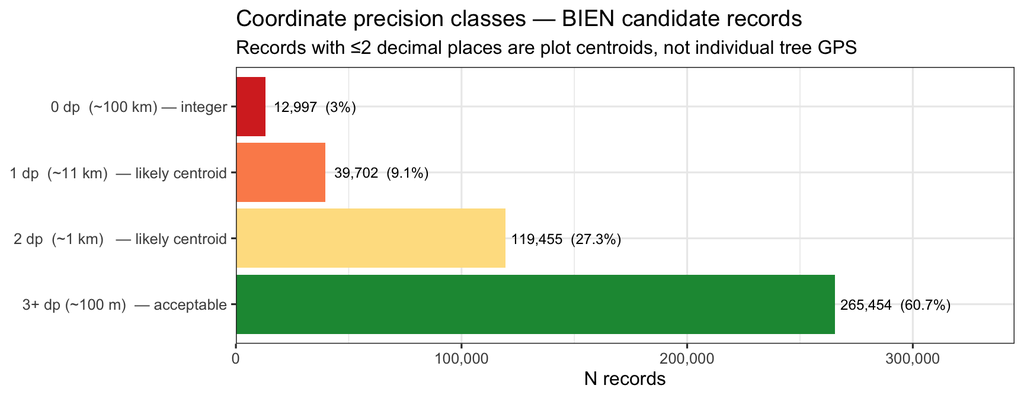

```r
ggplot(prec_summary, aes(x = reorder(coord_precision_class, -n), y = n, fill = coord_precision_class)) +
  geom_col(show.legend = FALSE) +
  geom_text(aes(label = paste0(format(n, big.mark=","), "  (", pct, "%)")),
            hjust = -0.05, size = 3.2) +
  coord_flip() +
  scale_y_continuous(labels = comma, expand = expansion(mult = c(0, 0.3))) +
  scale_fill_manual(values = c(
    "0 dp  (~100 km) — integer"    = "#d73027",
    "1 dp  (~11 km)  — likely centroid" = "#fc8d59",
    "2 dp  (~1 km)   — likely centroid" = "#fee090",
    "3+ dp (~100 m)  — acceptable" = "#1a9641"
  )) +
  labs(x = NULL, y = "N records",
       title = "Coordinate precision classes — BIEN candidate records",
       subtitle = "Records with ≤2 decimal places are plot centroids, not individual tree GPS")
```

```r
top_coords <- tallo_id |>
  count(latitude, longitude, sort = TRUE) |>
  head(10)
kable(top_coords,
      caption = "Top 10 most-repeated coordinate pairs (confirms plot centroid structure)")
```

Top 10 most-repeated coordinate pairs (confirms plot centroid structure)

| latitude | longitude | n |
| --- | --- | --- |
| -17.120 | 145.632 | 23249 |
| 9.151 | -79.855 | 9777 |
| 45.980 | -77.900 | 6076 |
| 2.580 | 102.180 | 3617 |
| 16.898 | -90.980 | 3086 |
| 43.100 | 11.200 | 2979 |
| 40.800 | -2.300 | 2644 |
| -3.750 | -48.470 | 2160 |
| 62.500 | 29.200 | 2073 |
| 52.900 | 23.600 | 2071 |

## 11.3 Coordinate anomalies

```r
# lon = 0 cases
lon0 <- tallo |> filter(longitude == 0)
kable(lon0 |> select(tree_id, genus, species, latitude, longitude,
                     stem_diameter_cm, height_m, reference_id),
      caption = "Records with longitude = 0 (reference 35; Quercus ilex, Spain — verify against source publication)")
```

Records with longitude = 0 (reference 35; Quercus ilex, Spain — verify against source publication)

| tree_id | genus | species | latitude | longitude | stem_diameter_cm | height_m | reference_id |
| --- | --- | --- | --- | --- | --- | --- | --- |
| T_222992 | Quercus | Quercus ilex | 40.558 | 0 | 12.9 | 6.0 | 35 |
| T_234079 | Quercus | Quercus ilex | 40.297 | 0 | 15.1 | 5.5 | 35 |
| T_234561 | Quercus | Quercus ilex | 40.297 | 0 | 15.2 | 5.0 | 35 |
| T_235119 | Quercus | Quercus ilex | 40.297 | 0 | 15.3 | 5.0 | 35 |
| T_243833 | Quercus | Quercus ilex | 40.558 | 0 | 17.8 | 6.5 | 35 |
| T_271666 | Quercus | Quercus ilex | 40.558 | 0 | 28.6 | 6.5 | 35 |

```r
# Implausible height record
implausible <- tallo |> filter(is.na(species) & !is.na(height_m) & height_m > 90)
if (nrow(implausible) > 0) {
  kable(implausible |> select(tree_id, genus, species, latitude, longitude,
                               height_m, stem_diameter_cm, reference_id),
        caption = "Unidentified records with height > 90 m — ecologically implausible for most regions; quarantine before BIEN import")
}
```

Unidentified records with height > 90 m — ecologically implausible for most regions; quarantine before BIEN import

| tree_id | genus | species | latitude | longitude | height_m | stem_diameter_cm | reference_id |
| --- | --- | --- | --- | --- | --- | --- | --- |
| T_481206 | NA | NA | 31.198 | -84.469 | 102.7 | 13.6 | 65 |

## 11.4 BIEN candidate pool summary

```r
pool <- tallo_id |>
  summarise(
    `Total BIEN candidates (species non-NA)` = n(),
    `With 3+ dp coords (GPS quality)`        = sum(min_dp >= 3),
    `Plot centroids (≤2 dp)`                 = sum(is_plot_centroid),
    `With height_m`                          = sum(!is.na(height_m)),
    `With crown_radius_m`                    = sum(!is.na(crown_radius_m)),
    `height_outlier flagged`                 = sum(height_outlier == "Y"),
    `crown_radius_outlier flagged`           = sum(crown_radius_outlier == "Y"),
    `Height < 2 m (sapling/juvenile)`        = sum(!is.na(height_m) & height_m < 2)
  ) |>
  tidyr::pivot_longer(everything(), names_to = "Metric", values_to = "N") |>
  mutate(Pct = round(100 * N / n(), 1))
kable(pool, caption = "BIEN candidate pool summary (437,608 records with species binomial)")
```

BIEN candidate pool summary (437,608 records with species binomial)

[output not shown]

## 11.5 Trait units — BIEN canonical mapping

All three Tallo trait fields are already in appropriate SI-derived units; no numeric conversion is required. Field renaming and protocol flagging are needed.

```r
kable(data.frame(
  `Tallo field`        = c("stem_diameter_cm", "height_m", "crown_radius_m"),
  `BIEN canonical`     = c("stem_diameter_cm", "plant_height_m", "crown_radius_m"),
  Unit                 = c("cm", "m", "m"),
  `Conversion needed`  = c("None", "None", "None"),
  Notes = c(
    "Multi-stemmed trees use sqrt(sum(Di²)) — flag with measurement_protocol = 'multi_stem_quadratic_sum'",
    "Outliers flagged by source authors; preserve flag as measurementRemarks",
    "37.3% missing; missingness is by-reference (non-random) — do not impute"
  )
), caption = "Tallo → BIEN canonical trait unit mapping")
```

Tallo → BIEN canonical trait unit mapping

| Tallo.field | BIEN.canonical | Unit | Conversion.needed | Notes |
| --- | --- | --- | --- | --- |
| stem_diameter_cm | stem_diameter_cm | cm | None | Multi-stemmed trees use sqrt(sum(Di²)) — flag with measurement_protocol = ‘multi_stem_quadratic_sum’ |
| height_m | plant_height_m | m | None | Outliers flagged by source authors; preserve flag as measurementRemarks |
| crown_radius_m | crown_radius_m | m | None | 37.3% missing; missingness is by-reference (non-random) — do not impute |